# PRACTICAL MACHINE LEARNING

## INTRODUCTION

The goal of our project is to predict the manner in which they did the exercise. This is the “classe” variable in the training set. We use appropriate variables to predict with. We create a report describing how we built our model, how we used cross validation, what we think the expected out of sample error is, and why we made the choices you did. We also use our prediction model to predict 20 different test cases.

## INPUT DATA

```r
ExoData=read.csv(file="pml-training.csv", na.strings=c("NA",""), header=TRUE)
nrow(ExoData)
```

```
## [1] 19622
```

```r
#str(ExoData)
dim(ExoData)
```

```
## [1] 19622   160
```

## FEATURES

```r
b=sapply(ExoData, function(x) sum(is.na(x)))
FullData=subset(ExoData,select=c(which(!b>0)), stringsAsFactors=FALSE)
#str(FullData)
dim(FullData)
```

```
## [1] 19622    60
```

which leaves use with only 60 variables to train on.

```r
smartData=FullData
smartData=smartData[,colSums(smartData != 0) != 0]
dim(smartData)
```

```
## [1] 19622    60
```

```r
s=sapply(smartData, function(x) sum(is.na(x)))
#str(smartData)
```

## RANDOM FOREST

We implement a random forest model using cross validation to control overfitting.

```r
library(caret)
library(mlbench)
```

```r
tData=smartData
tData$cvtd_timestamp=NULL #with these in, there was a factor level mismatch with final validation set
tData$new_window=NULL #  final validation set
dim(tData)
```

```
## [1] 19622    58
```

```r
trainIdx=createDataPartition(tData$classe, p = .75, list=FALSE)
trainD=tData[trainIdx,]
testD=tData[-trainIdx,]
x <- trainD[,-58]
y <- trainD[,58]
```

```r
library(parallel)
library(doParallel)
cluster <- makeCluster(detectCores() - 1) # convention to leave 1 core for OS
registerDoParallel(cluster)
```

## CROSS VALIDATION

we use 10-folds cross validation to control overfitting.

```r
fitControl <- trainControl(method = "cv",
                           number = 10,
                           allowParallel = TRUE)
```

### Training

```r
fit <- train(x,y, method="rf",data=trainD,trControl = fitControl)
```

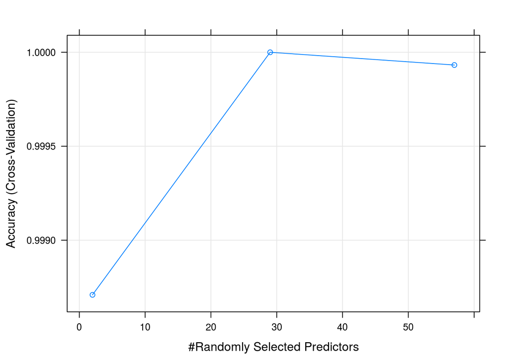

```r
plot(fit)
```

### Confusion Matrix

```r
rf.pred=predict(fit,testD[,-58])
confusionMat=table(rf.pred,testD[,58])
confusionMat
```

```
##
## rf.pred    A    B    C    D    E
##       A 1395    0    0    0    0
##       B    0  949    0    0    0
##       C    0    0  855    0    0
##       D    0    0    0  804    0
##       E    0    0    0    0  901
```

### Suscpiciously High Accuracy

The results appear to be too precise to be true, which would mean we are probably overfitting. However, we are using cross validation to select the variables and it appears to peak above 0.9998 accuracy around 30 variables. We where unable to find an explanation for overfitting and suspect that the high performance on the test set is probably due to data being artificial and not having enough noise.

## Prediction Results

bellow the prediction results for the 20 test cases:

```r
vData=read.csv(file="pml-testing.csv", na.strings=c("NA",""), header=TRUE)
b=sapply(vData, function(x) sum(is.na(x)))
fvData=subset(vData,select=c(which(!b>0)), stringsAsFactors=FALSE)
#str(vData)
#dim(vData)
svData=fvData
svData=svData[,colSums(svData != 0) != 0]
dim(svData)
```

```
## [1] 20 60
```

```r
s=sapply(svData, function(x) sum(is.na(x)))
#str(svData)
```

```r
validationData=svData
validationData$cvtd_timestamp=NULL
validationData$new_window=NULL
#nrow(validationData)
#str(validationData)
#dim(validationData)
validation.pred=predict(fit, validationData)
validation.pred
```

```
##  [1] A A A A A A A A A A A A A A A A A A A A
## Levels: A B C D E
```